# Guided Project: Exploring NYC Schools Survey Data

Chun Hoe Leung

**R Instructions**

-This is an [R Markdown](http://rmarkdown.rstudio.com) Notebook. When you execute code within the notebook, the results appear beneath the code.

-Try executing this chunk by clicking the *Run* button within the chunk or by placing your cursor inside it and pressing *Ctrl+Shift+Enter*.

-Add a new chunk by clicking the *Insert Chunk* button on the toolbar or by pressing *Ctrl+Alt+I*.

-When you save the notebook, an HTML file containing the code and output will be saved alongside it (click the *Preview* button or press *Ctrl+Shift+K* to preview the HTML file).

-The preview shows you a rendered HTML copy of the contents of the editor. Consequently, unlike *Knit*, *Preview* does not run any R code chunks. Instead, the output of the chunk when it was last run in the editor is displayed.

In this project, I will analyze data from the New York City school department to understand whether parent, teacher, and student perceptions of the following factors affect average school SAT scores (an indicator of academic performance):

1. Safety
2. Engagement
3. Communication
4. Academics

The data, collected in 2011, are publicly available and can be accessed [here](https://data.cityofnewyork.us/Education/2011-NYC-School-Survey/mnz3-dyi8).

I’ll start by installing the packages that I’ll need for this analysis:

```r
library(readr)
library(dplyr)
```

```r
library(stringr)
library(purrr)
library(tidyr)
library(ggplot2)
```

###3. New York City Schools Survey Data Import data into R

```r
combined<-read_csv("~/CHL/DataQuest R/combined.csv")
survey<-read_tsv("~/CHL/DataQuest R/masterfile11_gened_final.txt")
survey_d75<-read_tsv("~/CHL/DataQuest R/masterfile11_d75_final.txt")
```

EDA Combined

```r
head(combined)
```

| DBN | school_name | Num of SAT Test Takers | SAT Critical Reading Avg. Score | SAT Math Avg. Score | SAT Writing Avg. Score | avg_sat_score | AP Test Takers | Total Exams Taken | Number of Exams with scores 3 4 or 5 | exams_per_student | high_score_percent | avg_class_size | frl_percent | total_enrollment | ell_percent | sped_percent | selfcontained_num | asian_per | black_per | hispanic_per | white_per | male_per | female_per | Total Cohort | grads_percent | dropout_percent | boro | lat | long |
| --- | --- | --- | --- | --- | --- | --- | --- | --- | --- | --- | --- | --- | --- | --- | --- | --- | --- | --- | --- | --- | --- | --- | --- | --- | --- | --- | --- | --- | --- |
| 01M292 | HENRY STREET SCHOOL FOR INTERNATIONAL STUDIES | 29 | 355 | 404 | 363 | 1122 | 2.5 | NA | NA | NA | NA | 23 | 88.6 | 422 | 22.3 | 24.9 | 35 | 14.0 | 29.1 | 53.8 | 1.7 | 61.4 | 38.6 | 78 | 55.1 | 14.1 | Manhattan | 40.71376 | -73.98526 |
| 01M448 | UNIVERSITY NEIGHBORHOOD HIGH SCHOOL | 91 | 383 | 423 | 366 | 1172 | 39.0 | 49 | 10 | 1.256410 | 20.40816 | 22 | 71.8 | 394 | 21.1 | 21.8 | 10 | 29.2 | 22.6 | 45.9 | 2.3 | 57.4 | 42.6 | 124 | 42.7 | 16.1 | Manhattan | 40.71233 | -73.98480 |
| 01M450 | EAST SIDE COMMUNITY SCHOOL | 70 | 377 | 402 | 370 | 1149 | 19.0 | 21 | NA | 1.105263 | NA | 21 | 71.8 | 598 | 5.0 | 26.4 | 19 | 9.7 | 23.9 | 55.4 | 10.4 | 54.7 | 45.3 | 90 | 77.8 | 5.6 | Manhattan | 40.72978 | -73.98304 |
| 01M458 | FORSYTH SATELLITE ACADEMY | 7 | 414 | 401 | 359 | 1174 | 2.5 | NA | NA | NA | NA | 23 | 72.8 | 224 | 4.0 | 8.9 | 0 | 2.2 | 34.4 | 59.4 | 3.6 | 43.3 | 56.7 | NA | NA | NA | NA | NA | NA |
| 01M509 | MARTA VALLE HIGH SCHOOL | 44 | 390 | 433 | 384 | 1207 | 2.5 | NA | NA | NA | NA | 24 | 80.7 | 367 | 11.2 | 25.9 | 36 | 9.3 | 31.6 | 56.9 | 1.6 | 46.3 | 53.7 | 84 | 56.0 | 6.0 | Manhattan | 40.72057 | -73.98567 |
| 01M515 | LOWER EAST SIDE PREPARATORY HIGH SCHOOL | 112 | 332 | 557 | 316 | 1205 | 24.0 | 26 | 24 | 1.083333 | 92.30769 | 23 | NA | NA | NA | NA | NA | NA | NA | NA | NA | NA | NA | 193 | 54.4 | 18.1 | NA | NA | NA |

```r
dim(combined)
```

```
## [1] 479  30
```

EDA Survey

```r
head(survey)
```

| dbn | bn | schoolname | d75 | studentssurveyed | highschool | schooltype | rr_s | rr_t | rr_p | N_s | N_t | N_p | nr_s | nr_t | nr_p | saf_p_11 | com_p_11 | eng_p_11 | aca_p_11 | saf_t_11 | com_t_11 | eng_t_11 | aca_t_11 | saf_s_11 | com_s_11 | eng_s_11 | aca_s_11 | saf_tot_11 | com_tot_11 | … |
| --- | --- | --- | --- | --- | --- | --- | --- | --- | --- | --- | --- | --- | --- | --- | --- | --- | --- | --- | --- | --- | --- | --- | --- | --- | --- | --- | --- | --- | --- | --- |
| 01M015 | M015 | P.S. 015 Roberto Clemente | 0 | No | 0 | Elementary School | NA | 88 | 60 | NA | 22 | 90 | 0 | 25 | 150 | 8.5 | 7.6 | 7.5 | 7.8 | 7.5 | 7.8 | 7.6 | 7.9 | NA | NA | NA | NA | 8.0 | 7.7 | … |
| 01M019 | M019 | P.S. 019 Asher Levy | 0 | No | 0 | Elementary School | NA | 100 | 60 | NA | 34 | 161 | 0 | 33 | 269 | 8.4 | 7.6 | 7.6 | 7.8 | 8.6 | 8.5 | 8.9 | 9.1 | NA | NA | NA | NA | 8.5 | 8.1 | … |
| 01M020 | M020 | P.S. 020 Anna Silver | 0 | No | 0 | Elementary School | NA | 88 | 73 | NA | 42 | 367 | 0 | 48 | 505 | 8.9 | 8.3 | 8.3 | 8.6 | 7.6 | 6.3 | 6.8 | 7.5 | NA | NA | NA | NA | 8.2 | 7.3 | … |
| 01M034 | M034 | P.S. 034 Franklin D. Roosevelt | 0 | Yes | 0 | Elementary / Middle School | 89 | 73 | 50 | 145 | 29 | 151 | 163 | 40 | 301 | 8.8 | 8.2 | 8.0 | 8.5 | 7.0 | 6.2 | 6.8 | 7.8 | 6.2 | 5.9 | 6.5 | 7.4 | 7.3 | 6.7 | … |
| 01M063 | M063 | P.S. 063 William McKinley | 0 | No | 0 | Elementary School | NA | 100 | 60 | NA | 23 | 90 | 0 | 23 | 151 | 8.7 | 7.9 | 8.1 | 7.9 | 8.4 | 7.3 | 7.8 | 8.1 | NA | NA | NA | NA | 8.5 | 7.6 | … |
| 01M064 | M064 | P.S. 064 Robert Simon | 0 | No | 0 | Elementary School | NA | 94 | 61 | NA | 32 | 159 | 0 | 34 | 262 | 8.8 | 8.2 | 8.2 | 8.5 | 8.6 | 7.6 | 8.3 | 8.5 | NA | NA | NA | NA | 8.7 | 7.9 | … |

```r
dim(survey)
```

```
## [1] 1646 1942
```

EDA survey_d75

```r
head(survey_d75)
```

| dbn | bn | schoolname | d75 | studentssurveyed | highschool | schooltype | rr_s | rr_t | rr_p | N_s | N_t | N_p | nr_s | nr_t | nr_p | saf_p_11 | com_p_11 | eng_p_11 | aca_p_11 | saf_t_11 | com_t_11 | eng_t_11 | aca_t_11 | saf_s_11 | com_s_11 | eng_s_11 | aca_s_11 | saf_tot_11 | com_tot_11 | … |
| --- | --- | --- | --- | --- | --- | --- | --- | --- | --- | --- | --- | --- | --- | --- | --- | --- | --- | --- | --- | --- | --- | --- | --- | --- | --- | --- | --- | --- | --- | --- |
| 75K004 | K004 | P.S. K004 | 1 | Yes | 0 | District 75 Special Education | 38 | 90 | 72 | 8 | 81 | 244 | 21 | 90 | 337 | 9.1 | 8.6 | 8.4 | 8.5 | 7.4 | 6.6 | 6.4 | 6.4 | 7.6 | 5.8 | 7.6 | 6.3 | 8.0 | 7.0 | … |
| 75K036 | K036 | P.S. 36 | 1 | Yes | NA | District 75 Special Education | 70 | 69 | 44 | 97 | 43 | 115 | 139 | 62 | 263 | 9.2 | 8.7 | 8.6 | 8.8 | 6.9 | 7.1 | 6.1 | 7.2 | 6.6 | 6.9 | 7.3 | 7.7 | 7.5 | 7.6 | … |
| 75K053 | K053 | P.S. K053 | 1 | Yes | NA | District 75 Special Education | 94 | 97 | 53 | 131 | 75 | 189 | 139 | 77 | 355 | 8.8 | 8.1 | 8.0 | 8.1 | 7.8 | 7.5 | 6.9 | 8.0 | 8.2 | 7.7 | 8.6 | 8.5 | 8.2 | 7.8 | … |
| 75K077 | K077 | P.S. K077 | 1 | Yes | NA | District 75 Special Education | 95 | 65 | 55 | 70 | 52 | 150 | 74 | 80 | 274 | 9.4 | 8.7 | 8.8 | 8.9 | 7.1 | 6.2 | 6.4 | 6.3 | 8.6 | 8.3 | 8.6 | 8.8 | 8.3 | 7.7 | … |
| 75K140 | K140 | P.S. K140 | 1 | Yes | 0 | District 75 Special Education | 77 | 70 | 42 | 69 | 45 | 117 | 90 | 64 | 277 | 8.6 | 8.2 | 7.9 | 8.3 | 5.6 | 5.8 | 5.1 | 6.0 | 4.7 | 6.1 | 6.0 | 7.3 | 6.3 | 6.7 | … |
| 75K141 | K141 | P.S. K141 | 1 | Yes | NA | District 75 Special Education | 73 | 55 | 29 | 53 | 43 | 105 | 73 | 78 | 364 | 8.8 | 8.0 | 7.9 | 8.0 | 6.0 | 4.8 | 4.9 | 5.1 | 6.1 | 6.2 | 7.3 | 7.6 | 6.9 | 6.3 | … |

```r
dim(survey_d75)
```

```
## [1]   56 1773
```

EDA Results -Key to join the survey data to the combined data set= “DBN”

###4. Simplifying the Data Frames Simplify survey and survey_d75 by including only relevant variables

```r
survey_select<-survey%>%
  select(dbn:aca_tot_11)
dim(survey_select)
```

```
## [1] 1646   32
```

```r
survey_d75_select<-survey_d75%>%
  select(dbn:aca_tot_11)
dim(survey_d75_select)
```

```
## [1] 56 32
```

Explore variations of schooltype

```r
unique(survey_select$schooltype)
```

```
## [1] "Elementary School"                 "Elementary / Middle School"
## [3] "Middle / High School"              "Middle School"
## [5] "High School"                       "Elementary / Middle / High School"
## [7] "Early Childhood School"            "YABC"
```

```r
unique(survey_d75_select$schooltype)
```

```
## [1] "District 75 Special Education"
```

Filter survey DF to include only observations for high schools

```r
survey_select<-survey_select%>%
  filter(schooltype=="High School")
dim(survey_select)
```

```
## [1] 383  32
```

###5. Creating a Single Data Frame for Analysis Combine the general education and District 75 survey data frames using the dplyr function bind_rows()

```r
survey_combined<-bind_rows(survey_select,survey_d75_select)
dim(survey_combined)
```

```
## [1] 439  32
```

Check to make sure that there is a key you can use.

```r
combined_column_names<-colnames(combined)
print("combined")
```

```
## [1] "combined"
```

```r
print(combined_column_names)
```

```
##  [1] "DBN"
##  [2] "school_name"
##  [3] "Num of SAT Test Takers"
##  [4] "SAT Critical Reading Avg. Score"
##  [5] "SAT Math Avg. Score"
##  [6] "SAT Writing Avg. Score"
##  [7] "avg_sat_score"
##  [8] "AP Test Takers"
##  [9] "Total Exams Taken"
## [10] "Number of Exams with scores 3 4 or 5"
## [11] "exams_per_student"
## [12] "high_score_percent"
## [13] "avg_class_size"
## [14] "frl_percent"
## [15] "total_enrollment"
## [16] "ell_percent"
## [17] "sped_percent"
## [18] "selfcontained_num"
## [19] "asian_per"
## [20] "black_per"
## [21] "hispanic_per"
## [22] "white_per"
## [23] "male_per"
## [24] "female_per"
## [25] "Total Cohort"
## [26] "grads_percent"
## [27] "dropout_percent"
## [28] "boro"
## [29] "lat"
## [30] "long"
```

```r
survey_combined_names<-colnames(survey_combined)
print("survey_combined")
```

```
## [1] "survey_combined"
```

```r
print(survey_combined_names)
```

```
##  [1] "dbn"              "bn"               "schoolname"
##  [4] "d75"              "studentssurveyed" "highschool"
##  [7] "schooltype"       "rr_s"             "rr_t"
## [10] "rr_p"             "N_s"              "N_t"
## [13] "N_p"              "nr_s"             "nr_t"
## [16] "nr_p"             "saf_p_11"         "com_p_11"
## [19] "eng_p_11"         "aca_p_11"         "saf_t_11"
## [22] "com_t_11"         "eng_t_11"         "aca_t_11"
## [25] "saf_s_11"         "com_s_11"         "eng_s_11"
## [28] "aca_s_11"         "saf_tot_11"       "com_tot_11"
## [31] "eng_tot_11"       "aca_tot_11"
```

Rename variables

```r
survey_combined<-survey_combined%>%
  rename(DBN=dbn,school_name=schoolname)
print(colnames(survey_combined))
```

```
##  [1] "DBN"              "bn"               "school_name"
##  [4] "d75"              "studentssurveyed" "highschool"
##  [7] "schooltype"       "rr_s"             "rr_t"
## [10] "rr_p"             "N_s"              "N_t"
## [13] "N_p"              "nr_s"             "nr_t"
## [16] "nr_p"             "saf_p_11"         "com_p_11"
## [19] "eng_p_11"         "aca_p_11"         "saf_t_11"
## [22] "com_t_11"         "eng_t_11"         "aca_t_11"
## [25] "saf_s_11"         "com_s_11"         "eng_s_11"
## [28] "aca_s_11"         "saf_tot_11"       "com_tot_11"
## [31] "eng_tot_11"       "aca_tot_11"
```

Join the new survey data frame you created to the combined data frame that contains the NYC schools data you cleaned in this mission.

```r
single_DF<-combined%>%left_join(survey_combined,by="DBN")
dim(single_DF)
```

```
## [1] 479  61
```

###6. Look for Interesting Correlations and Examine Relationships Using Scatter Plots Create a correlation matrix to look for interesting relationships between pairs of variables in the new, combined data frame you created.

```r
cor_mat<-single_DF%>%
  select(avg_sat_score,saf_p_11:aca_tot_11)%>%
  cor(use="pairwise.complete.obs")

#print(cor_mat)
```

convert the correlation matrix to a tibble

```r
cor_tib<-cor_mat%>%
  as_tibble(rownames="variable")
print(cor_tib)
```

```
## # A tibble: 17 x 18
##    variable avg_sat_score saf_p_11 com_p_11 eng_p_11 aca_p_11 saf_t_11
##    <chr>            <dbl>    <dbl>    <dbl>    <dbl>    <dbl>    <dbl>
##  1 avg_sat~       1         0.0891   -0.114  0.00943  0.00828    0.309
##  2 saf_p_11       0.0891    1         0.803  0.798    0.817      0.490
##  3 com_p_11      -0.114     0.803     1      0.929    0.926      0.315
##  4 eng_p_11       0.00943   0.798     0.929  1        0.908      0.339
##  5 aca_p_11       0.00828   0.817     0.926  0.908    1          0.415
##  6 saf_t_11       0.309     0.490     0.315  0.339    0.415      1
##  7 com_t_11       0.107     0.232     0.241  0.268    0.286      0.744
##  8 eng_t_11       0.0561    0.314     0.307  0.330    0.373      0.799
##  9 aca_t_11       0.141     0.364     0.347  0.359    0.419      0.845
## 10 saf_s_11       0.277     0.732     0.541  0.539    0.593      0.592
## 11 com_s_11       0.162     0.617     0.569  0.545    0.598      0.383
## 12 eng_s_11       0.170     0.647     0.591  0.608    0.623      0.457
## 13 aca_s_11       0.293     0.692     0.615  0.624    0.680      0.493
## 14 saf_tot~       0.276     0.828     0.611  0.621    0.683      0.844
## 15 com_tot~       0.0891    0.642     0.693  0.682    0.712      0.736
## 16 eng_tot~       0.0948    0.664     0.671  0.710    0.720      0.757
## 17 aca_tot~       0.174     0.700     0.703  0.705    0.789      0.782
## # ... with 11 more variables: com_t_11 <dbl>, eng_t_11 <dbl>,
## #   aca_t_11 <dbl>, saf_s_11 <dbl>, com_s_11 <dbl>, eng_s_11 <dbl>,
## #   aca_s_11 <dbl>, saf_tot_11 <dbl>, com_tot_11 <dbl>, eng_tot_11 <dbl>,
## #   aca_tot_11 <dbl>
```

Look for correlations of other variables with `avg_sat_score` that are greater than 0.25 or less than -0.25 (strong correlations).

```r
strong_correlations<-cor_tib%>%
  select(variable,avg_sat_score)%>%
  filter(avg_sat_score > 0.25 | avg_sat_score < -0.25)
print(strong_correlations)
```

```
## # A tibble: 5 x 2
##   variable      avg_sat_score
##   <chr>                 <dbl>
## 1 avg_sat_score         1
## 2 saf_t_11              0.309
## 3 saf_s_11              0.277
## 4 aca_s_11              0.293
## 5 saf_tot_11            0.276
```

Make scatter plots of those variables with `avg_sat_score` to examine relationships more closely.

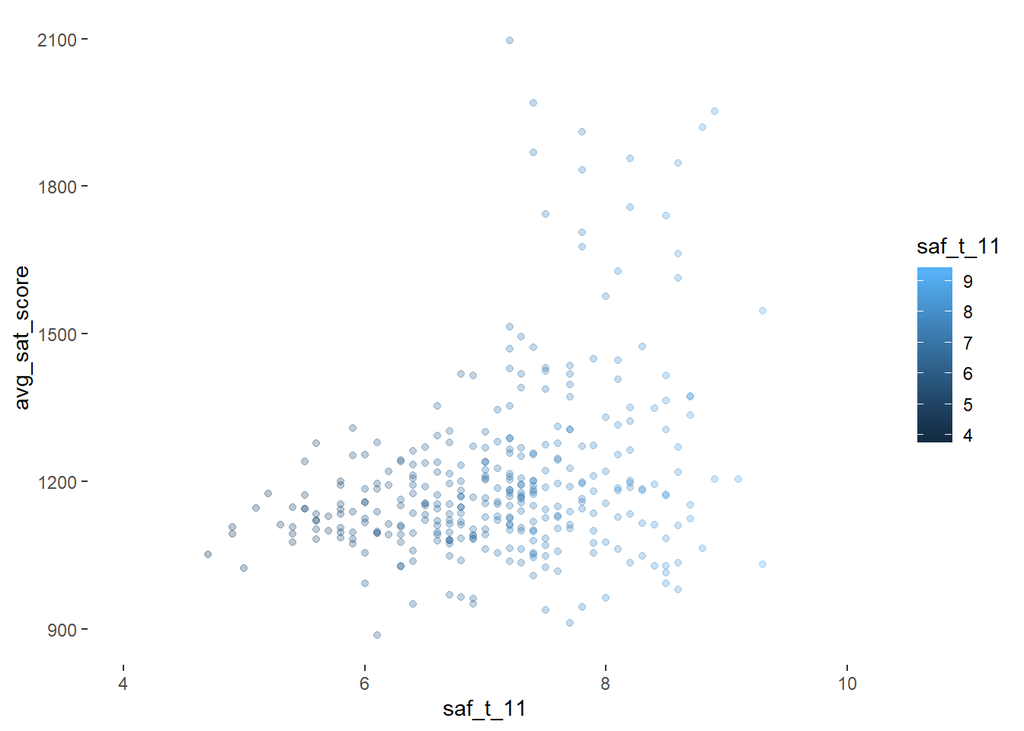

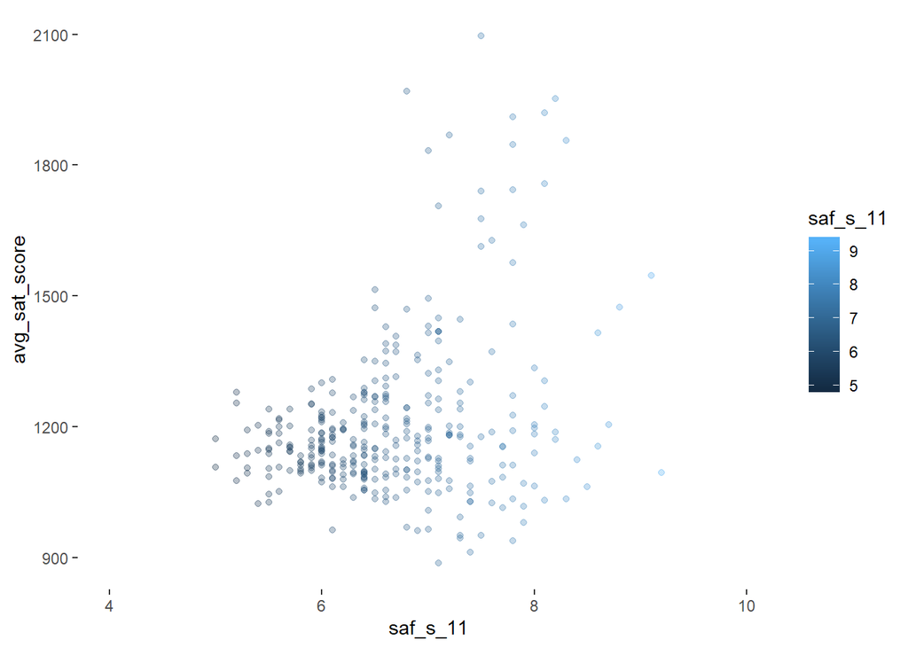

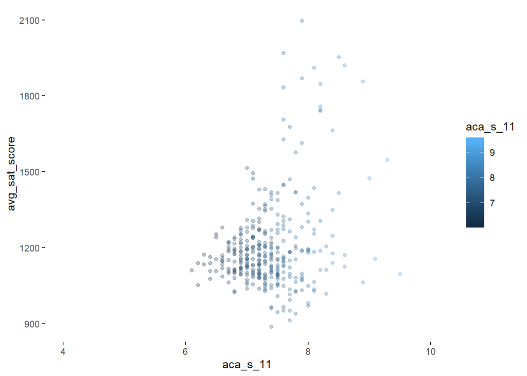

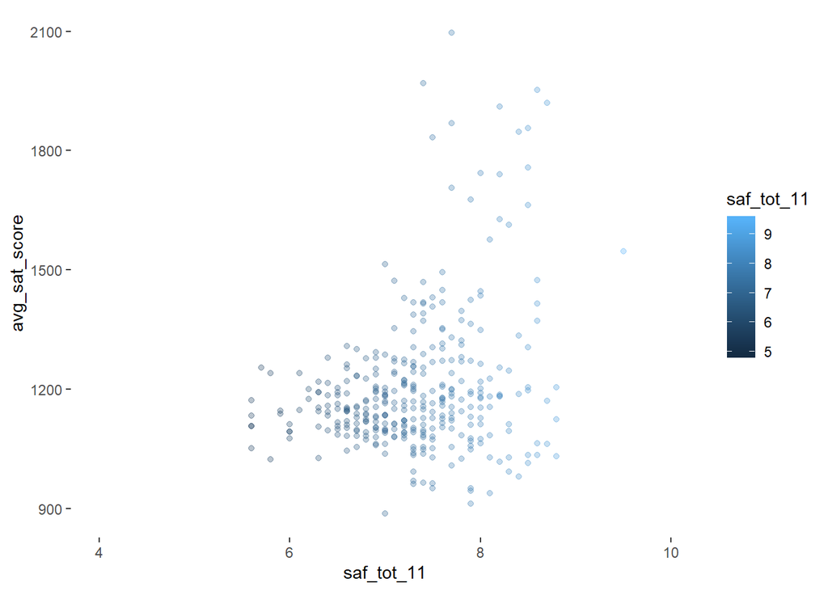

```r
create_scatter<-function(x,y){
  ggplot(data=single_DF)+
    aes_string(x=x,y=y,color=x)+
    geom_point(alpha=0.3)+
    theme(panel.background=element_rect(fill="white"))+
    xlim(4,10)
  }
x_var=strong_correlations$variable[2:5]
y_var=strong_correlations$variable[1]
scatter_plots<-map2(x_var,y_var,create_scatter)
print(scatter_plots)
```

Results of correlations results -avg_sat_score correlates moderate positive with the variables saf_t_11, saf_s_11, aca_s_11, saf_tot_11 -avg_sat_score correlates moderate positive with the variables saf_t_11, saf_s_11, saf_tot_11. However, weak or no correlation is found with saf_p_11. The opinion of both student and teacher are in line regarding safety and respect, but not with the parents opinion. -the academic expectations of the student correlates moderate positive with avg_sat_results.

###7. Differences in Student, Parent, and Teacher Perceptions: Reshape the Data Use the tidyr function gather() to reshape your data frame so that the survey question (like saf_p_11 and com_s_11) and the score (like 8.7 or 9.0) are in two separate columns.

```r
single_DF_gather<-single_DF%>%
  gather(key="survey_question",value=score,saf_p_11:aca_tot_11)
```

Create new variable “response_type”: With the values to indicate “parent,” “teacher,” “student,” or “total”

```r
print(unique(single_DF_gather$survey_question))
```

```
##  [1] "saf_p_11"   "com_p_11"   "eng_p_11"   "aca_p_11"   "saf_t_11"
##  [6] "com_t_11"   "eng_t_11"   "aca_t_11"   "saf_s_11"   "com_s_11"
## [11] "eng_s_11"   "aca_s_11"   "saf_tot_11" "com_tot_11" "eng_tot_11"
## [16] "aca_tot_11"
```

```r
single_DF_gather<-single_DF_gather%>%
  mutate(response_type=ifelse(str_sub(survey_question,4,6) == "_p_" , "parent",
                              ifelse(str_sub(survey_question,4,6) == "_t_" , "teacher",
                                     ifelse(str_sub(survey_question,4,6) =="_s_" , "student",
                                            ifelse(str_sub(survey_question,4,6) == "_to" , "total" , "NA")))))
```

Create new variable metric: With the values to indicate “engagement,” “academic expectations,” “safety and respect,” or “communication”

```r
single_DF_gather<-single_DF_gather%>%
  mutate(metric=str_sub(survey_question,1,3))

single_DF_gather<-single_DF_gather%>%
  mutate(metric=ifelse(metric == "saf" , "safety and respect",
                       ifelse(metric == "com" , "communication",
                              ifelse(metric == "eng" , "engagement",
                                     ifelse(metric == "aca" , "academic expectations" , "NA")))))
```

Explore differences in parent, teacher, and student perceptions of NYC school quality metrics using summary statistics or creating visualizations like box plots.

grouped_by_response_type

```r
grouped_by_response_type<-single_DF_gather%>%
  drop_na(score)%>%
  group_by(response_type,metric)%>%
  summarize(mean(score))
  #filter(metric=="academic expectations")

print(colnames(grouped_by_response_type))
```

```
## [1] "response_type" "metric"        "mean(score)"
```

```r
print(grouped_by_response_type)
```

```
## # A tibble: 16 x 3
## # Groups:   response_type [4]
##    response_type metric                `mean(score)`
##    <chr>         <chr>                         <dbl>
##  1 parent        academic expectations          7.83
##  2 parent        communication                  7.65
##  3 parent        engagement                     7.53
##  4 parent        safety and respect             8.19
##  5 student       academic expectations          7.38
##  6 student       communication                  6.13
##  7 student       engagement                     6.67
##  8 student       safety and respect             6.69
##  9 teacher       academic expectations          7.52
## 10 teacher       communication                  6.52
## 11 teacher       engagement                     7.01
## 12 teacher       safety and respect             7.13
## 13 total         academic expectations          7.58
## 14 total         communication                  6.76
## 15 total         engagement                     7.07
## 16 total         safety and respect             7.33
```

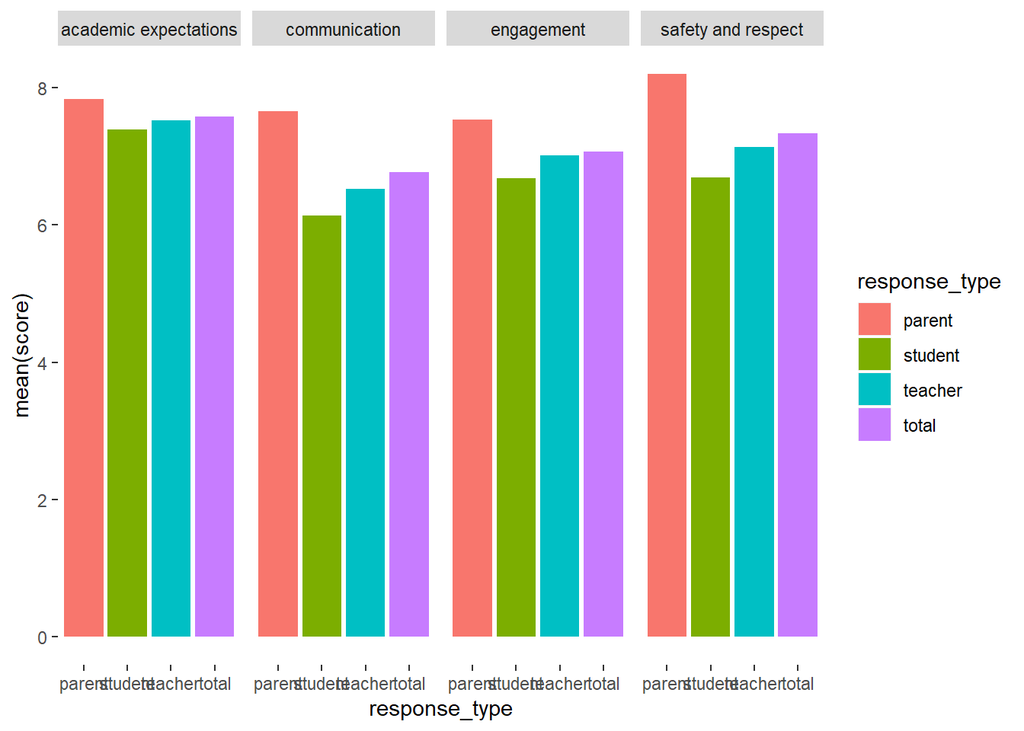

```r
ggplot(data=grouped_by_response_type)+
  aes(x=response_type,y=`mean(score)`,fill=response_type)+
  geom_bar(stat='identity')+
  theme(panel.background = element_rect(fill="white"))+
  facet_wrap(~metric,nrow=1)
```

```r
  labs(title="parent, teacher, and student perceptions of NYC school quality metrics")
```

```
## $title
## [1] "parent, teacher, and student perceptions of NYC school quality metrics"
##
## attr(,"class")
## [1] "labels"
```

grouped_by_metric

```r
grouped_by_metric<-single_DF_gather%>%
  drop_na(score)%>%
  group_by(metric,response_type)%>%
  summarize(mean(score))
  #filter(metric=="academic expectations")

print(grouped_by_metric)
```

```
## # A tibble: 16 x 3
## # Groups:   metric [4]
##    metric                response_type `mean(score)`
##    <chr>                 <chr>                 <dbl>
##  1 academic expectations parent                 7.83
##  2 academic expectations student                7.38
##  3 academic expectations teacher                7.52
##  4 academic expectations total                  7.58
##  5 communication         parent                 7.65
##  6 communication         student                6.13
##  7 communication         teacher                6.52
##  8 communication         total                  6.76
##  9 engagement            parent                 7.53
## 10 engagement            student                6.67
## 11 engagement            teacher                7.01
## 12 engagement            total                  7.07
## 13 safety and respect    parent                 8.19
## 14 safety and respect    student                6.69
## 15 safety and respect    teacher                7.13
## 16 safety and respect    total                  7.33
```

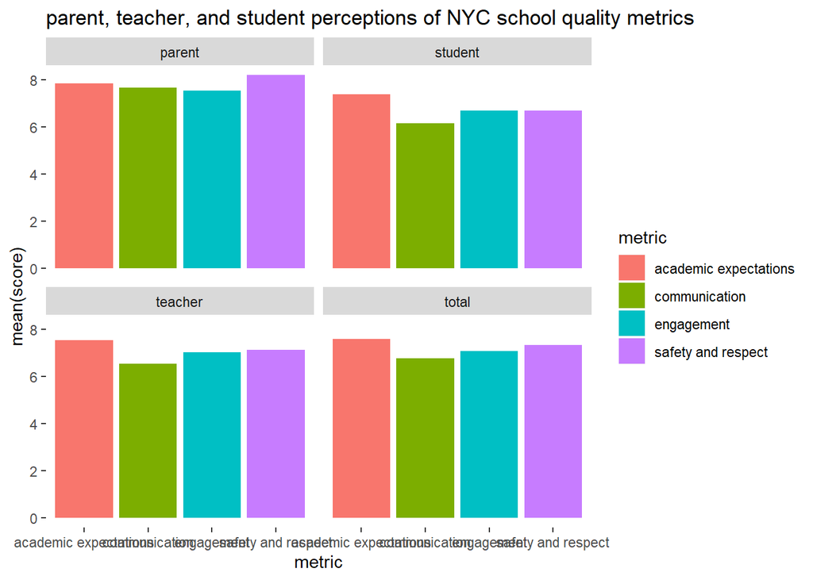

```r
ggplot(data=grouped_by_metric)+
  aes(x=metric,y=`mean(score)`,fill=metric)+
  geom_bar(stat='identity')+
  theme(panel.background = element_rect(fill="white"))+
  facet_wrap(~response_type)+
  labs(title="parent, teacher, and student perceptions of NYC school quality metrics")
```

Box Plots

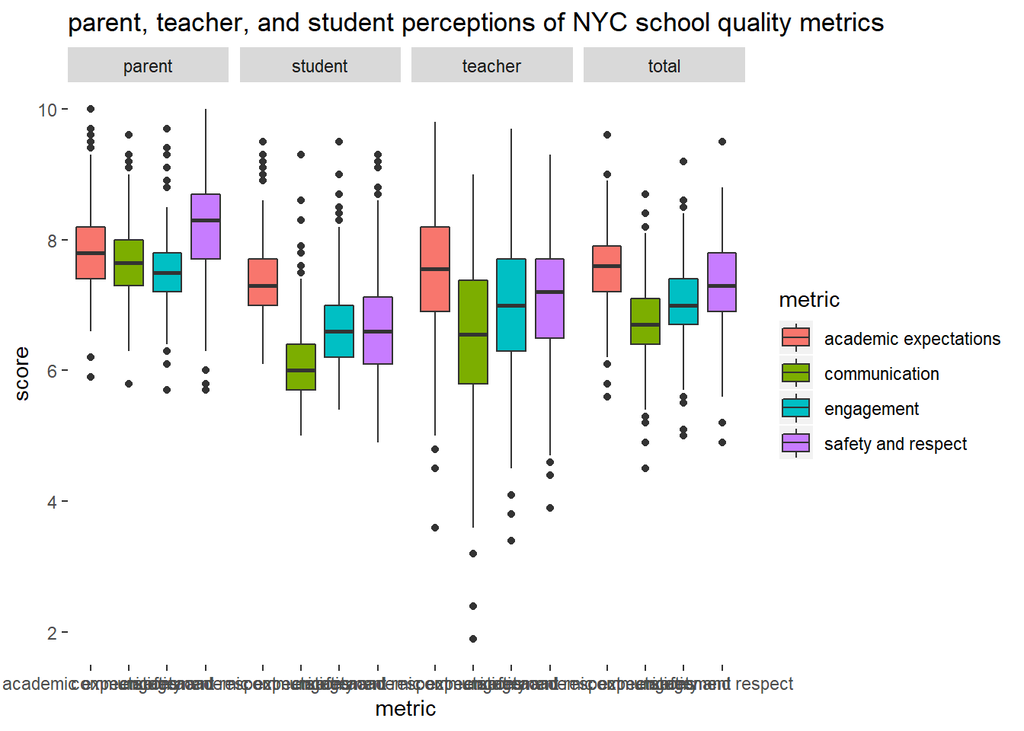

```r
ggplot(data=single_DF_gather)+
  aes(x=metric,y=score,fill=metric)+
  geom_boxplot()+
  theme(panel.background = element_rect(fill="white"))+
  facet_wrap(~response_type,nrow=1)+
  labs(title="parent, teacher, and student perceptions of NYC school quality metrics")
```

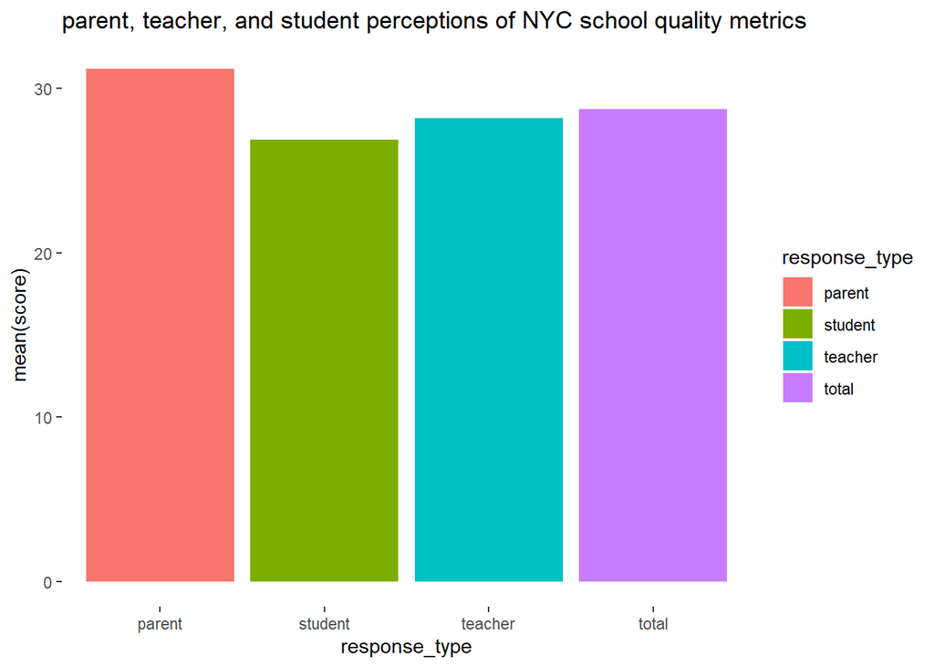

```r
ggplot(data=grouped_by_metric)+
  aes(x=response_type,y=`mean(score)`,fill=response_type)+
  geom_bar(stat='identity')+
  theme(panel.background = element_rect(fill="white"))+
  #facet_wrap(~response_type)+
  labs(title="parent, teacher, and student perceptions of NYC school quality metrics")
```

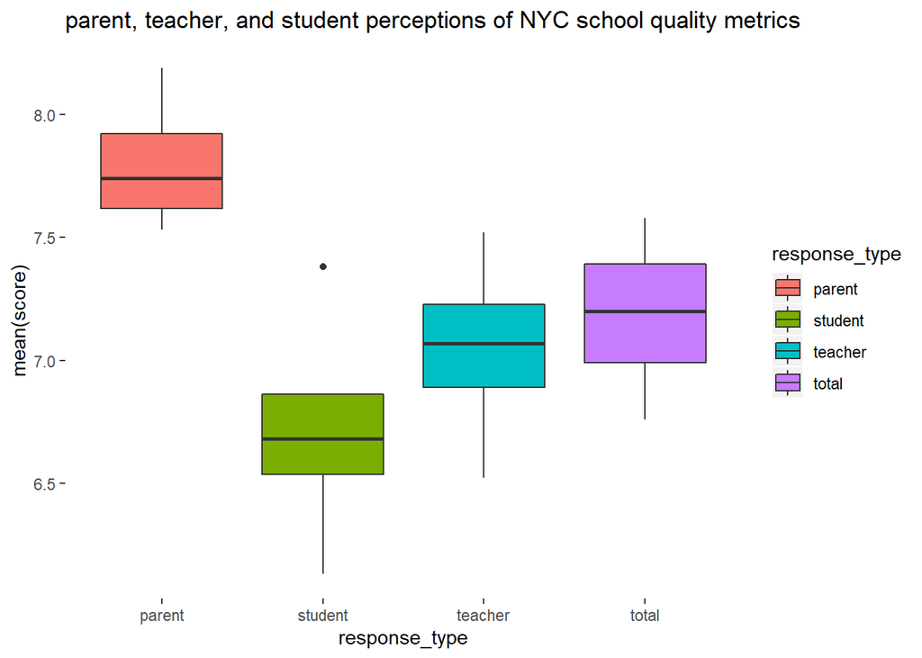

```r
ggplot(data=grouped_by_metric)+
  aes(x=response_type,y=`mean(score)`,fill=response_type)+
  geom_boxplot()+
  theme(panel.background = element_rect(fill="white"))+
  #facet_wrap(~response_type)+
  labs(title="parent, teacher, and student perceptions of NYC school quality metrics")
```

Correlations

```r
x_var=strong_correlations$variable[2:5]
y_var=strong_correlations$variable[1]
print(x_var)
```

```
## [1] "saf_t_11"   "saf_s_11"   "aca_s_11"   "saf_tot_11"
```

```r
print(y_var)
```

```
## [1] "avg_sat_score"
```

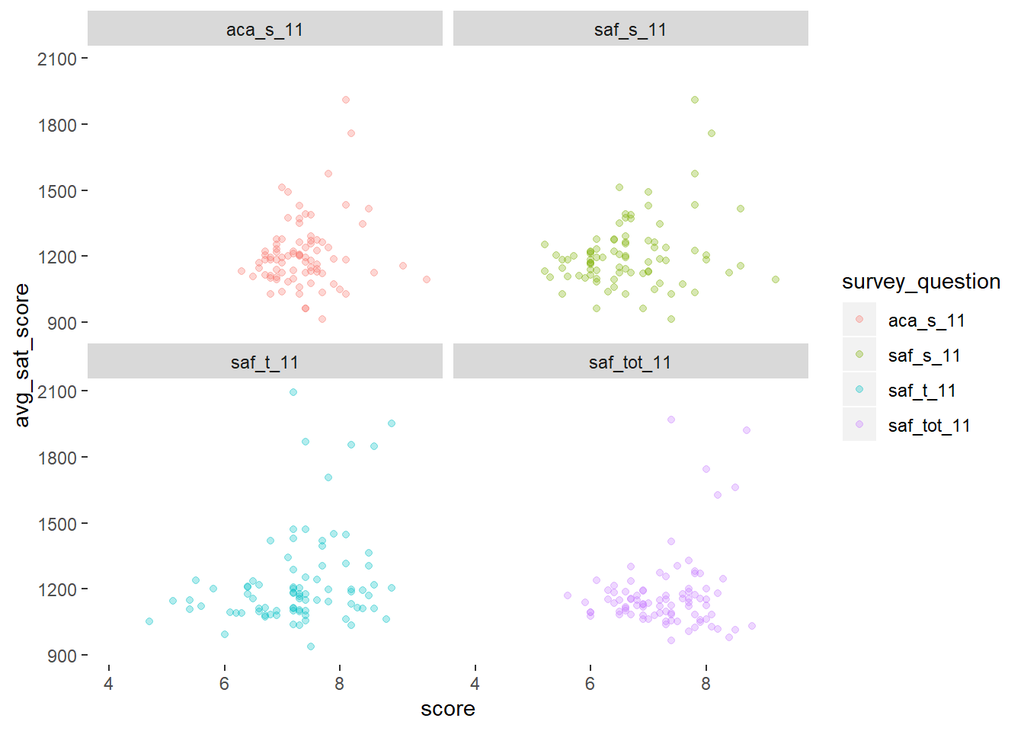

```r
single_DF_gather_filtered<-single_DF_gather%>%
  filter(survey_question == x_var)%>%
  drop_na(score)

ggplot(data=single_DF_gather_filtered)+
  aes(x=score,y=avg_sat_score,color=survey_question)+
  geom_point(alpha=0.3)+
  theme(panel.background=element_rect(fill="white"))+
  facet_wrap(~survey_question,nrow=2)
```

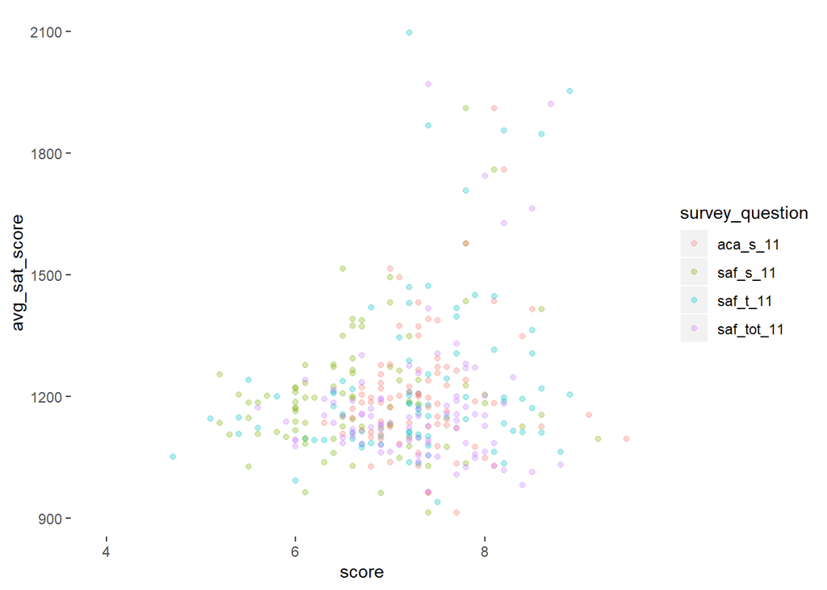

```r
ggplot(data=single_DF_gather_filtered)+
  aes(x=score,y=avg_sat_score,color=survey_question)+
  geom_point(alpha=0.3)+
  theme(panel.background=element_rect(fill="white"))
```

Findings -Parents have on average higher perceptions of NYC school quality metrics, while students have the lowest perceptions. -Teachers perceptions have the highest variance, while the parents perception have the lowest variance -Both teacher and student have higher perception on academic expectations, but the lowest on communication